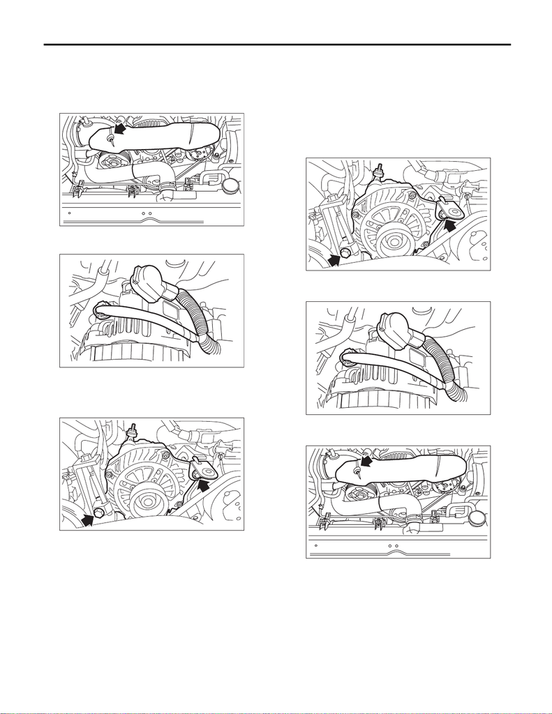

SC(STI)-15

Generator

STARTING/CHARGING SYSTEMS

3. Generator

A: REMOVAL

1) Disconnect the ground cable from battery.

2) Remove the V-belt covers.

3) Disconnect the connector and terminal from

generator.

4) Remove the front side belt. <Ref. to ME(STI)-41,

FRONT SIDE BELT, REMOVAL, V-belt.>

5) Remove the bolts which install the generator

onto bracket.

B: INSTALLATION

Install in the reverse order of removal.

CAUTION:

Check and adjust the front side belt tension.

<Ref. to ME(STI)-47, FRONT SIDE BELT, IN-

SPECTION, V-belt.>

Tightening torque:

25 N·m (2.5 kgf-m, 18.4 ft-lb)

Tightening torque:

16 N·m (1.6 kgf-m, 11.8 ft-lb)

Tightening torque:

13 N·m (1.3 kgf-m, 9.6 ft-lb)

FU-03487

SC-02154

SC-03059

SC-03059

SC-02154

FU-03487

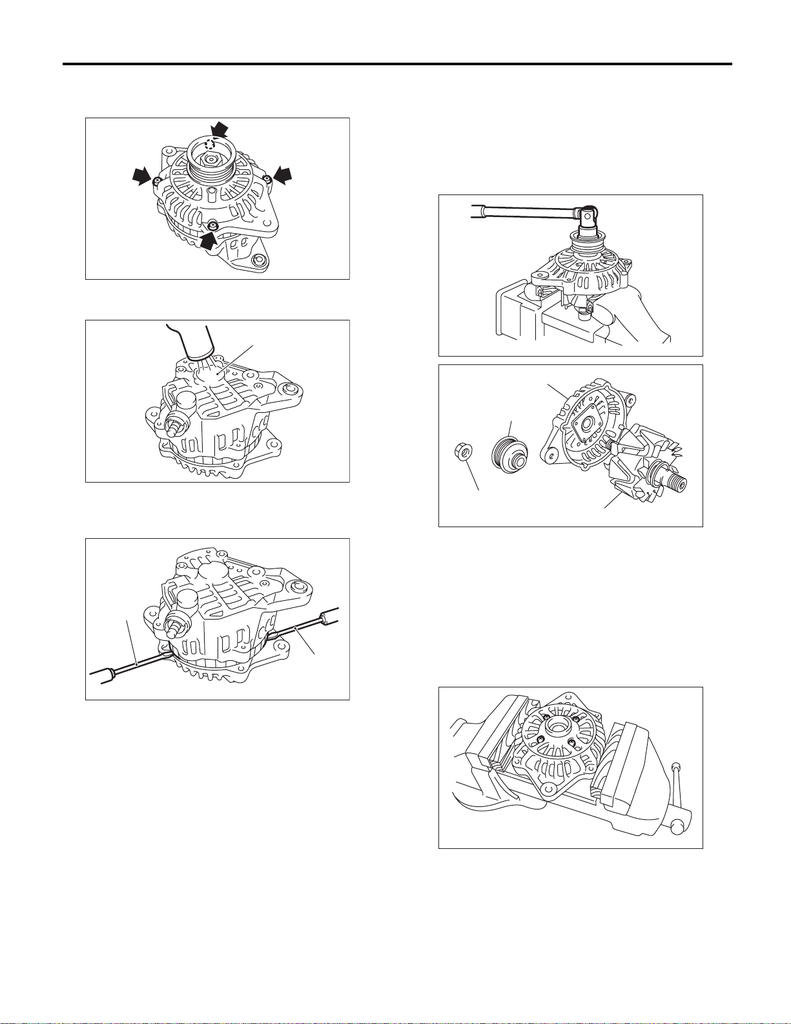

SC(STI)-16

Generator

STARTING/CHARGING SYSTEMS

C: DISASSEMBLY

1) Remove the four through-bolts.

2) Use a drier to heat the rear cover (A) portion to

50°C (122°F).

3) Insert the end of a flat tip screwdriver into the

gap between stator core and front cover. Pry them

apart to disassemble.

4) Using a vise, support the rotor and remove the

pulley nut, and remove the rotor from the front cov-

er.

CAUTION:

When holding the rotor with a vise, place alumi-

num plates or wooden pieces on the vise jaws

to prevent rotor from damage.

5) Use the following procedures to remove the ball

bearings.

(1) Remove the bolt, and then detach the bear-

ing retainer.

(A) Screwdriver

SC-00078

SC-00079

(A)

SC-00080

(A)

(A)

(A) Front cover

(B) Pulley

(C) Pulley nut

(D) Rotor

SC-00035

(A)

(B)

(C)

(D)

SC-00036

SC-00081

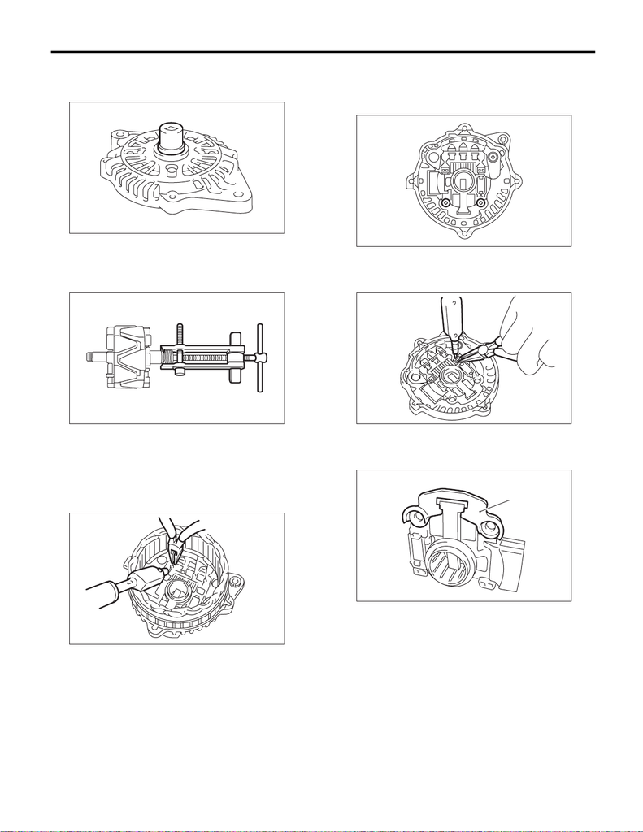

SC(STI)-17

Generator

STARTING/CHARGING SYSTEMS

(2) Firmly attach an appropriate tool (such as a

correct size socket wrench) to the bearing inner

race.

(3) Use the press to push the ball bearings out

from the front cover.

6) Using the bearing puller, remove the bearings

from the rotor.

7) Disconnect the connection between the rectifier

and stator coil, then remove the stator coil.

CAUTION:

The rectifier is easily damaged by heat. Do not

allow a 180 — 270 W soldering iron to contact

the terminals for 5 seconds or more at a time.

8) Use the following procedures to remove the IC

regulator.

(1) Remove the screws which secure the IC

regulator to the rear cover.

(2) Disconnect the connection between the IC

regulator and rectifier, then remove the IC reg-

ulator.

9) Use the following procedures to remove the

brush.

(1) Remove the cover A.

SC-00082

SC-00046

SC-00083

(A) Cover A

SC-00084

SC-00085

SC-00086

(A)

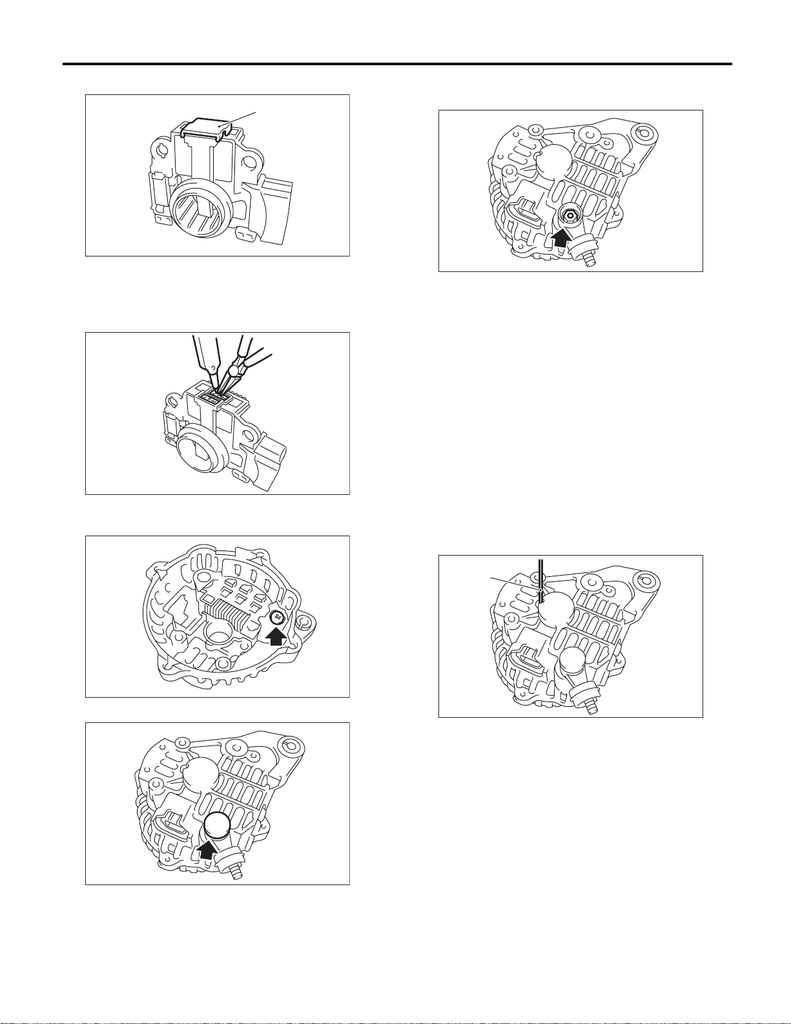

SC(STI)-18

Generator

STARTING/CHARGING SYSTEMS

(2) Remove the cover B.

(3) Disconnect the connection and remove the

brush.

10) Remove the rectifier as follows.

(1) Remove the bolts which secure the rectifier.

(2) Remove the cover on terminal B.

(3) Remove the nuts of terminal B, then remove

the rectifier.

D: ASSEMBLY

Assemble in the reverse order of disassembly.

NOTE:

• Refer to component for tightening torque of each

part. <Ref. to SC(STI)-4, GENERATOR, COMPO-

NENT, General Description.>

• After assembling, manually turn the pulley to

check that the rotor rotates smoothly.

1) Push of the brush

Before assembling the front and rear parts, press

the brush down into the brush holder, then fix the

through the hole as shown in the figure.

CAUTION:

After assembling, remove the wire.

2) Install the ball bearings

(1) Set the ball bearings in the front cover, then

securely install an appropriate tool (such as a

socket wrench of proper size) to the bearing

outer race.

(2) Using a press to press the ball bearings into

the specified location.

(3) Install the bearing retainer.

(A) Cover B

SC-00087

(A)

SC-00088

SC-00089

SC-00090

(A) Wire

SC-00091

SC-00092

(A)

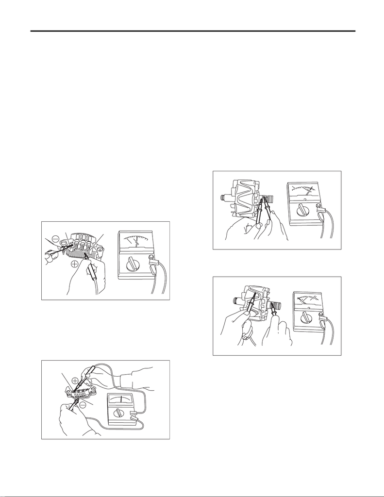

SC(STI)-19

Generator

STARTING/CHARGING SYSTEMS

3) Install the bearings.

CAUTION:

Do not apply grease to the bearings. If there is

any oil on the bearing box, remove it complete-

ly.

(1) Use a press to install the bearings to the ro-

tor shaft.

(2) Heat the bearing box in rear cover at 50 to

60°C (122 to 140°F), and then press the bear-

ing into rear cover.

E: INSPECTION

1. DIODE

CAUTION:

There is the possibility of damaging the diodes

if a mega-tester (used to measure high voltag-

es) or a similar measuring instrument is used.

Never use a mega tester or equivalent for this

test.

1) Check for continuity between the diode lead and

positive side heat sink. If resistance is 1 Ω or more

only in the direction from the diode lead to the heat

sink, replace the rectifier.

2) Check for continuity between the negative side

heat sink and diode lead. If resistance is 1 Ω or

more only in the direction from the heat sink to the

diode lead, replace the rectifier.

2. ROTOR

1) Inspect the slip rings for contamination or any

roughness on the sliding surface. Repair the slip

ring surface using a lathe or sand paper.

2) Measure the slip ring outer diameter. Replace

the rotor if the slip ring is worn.

Slip ring outer diameter:

Standard

22.7 mm (0.894 in)

Limit

22.1 mm (0.870 in)

3) Using a circuit tester, check the resistance be-

tween slip rings. If resistance exceeds the stan-

dard, replace the rotor.

Standard:

Approx. 1.8 — 2.2

Ω

4) Check the continuity between slip ring and rotor

core or shaft. If there is continuity, replace the rotor

because the rotor coil is grounded.

5) Check the bearings. If there is any noise, or the

rotor does not rotate smoothly, replace the bear-

ings.

(A) Diode lead

(B) Heat sink (positive side)

(A) Diode lead

(B) Heat sink (negative side)

SC-00042

(B)

(A)

(A)

(B)

SC-00043

SC-00044

SC-00045

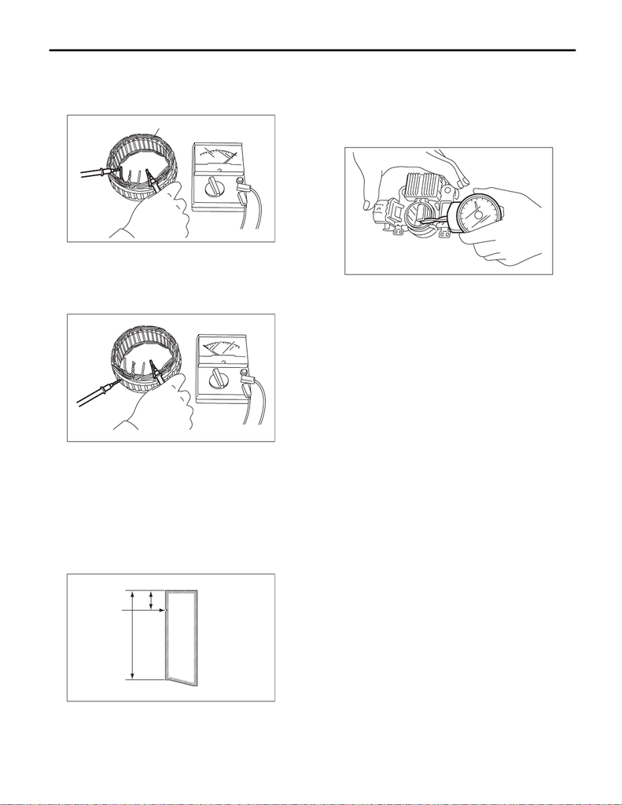

SC(STI)-20

Generator

STARTING/CHARGING SYSTEMS

3. STATOR COIL

1) Inspect continuity between the stator coil lead

wire terminals. If the resistance is 1 MΩ or more, re-

place the stator coil.

2) Inspect the continuity between the stator coil sta-

tor core and lead wire terminals. If the resistance is

1 Ω or less, replace the stator coil.

4. BRUSH

1) Measure the length of each brush. Replace the

brush if wear exceeds service limits. There is a ser-

vice limit mark (A) on each brush.

Brush length:

Standard (1)

18.5 mm (0.728 in)

Limit (2)

5.0 mm (0.197 in)

2) Using a spring pressure indicator, push the

brush into the brush holder until its tip protrudes 2

mm (0.08 in). Then measure the pressure of brush

spring. If the pressure is 2.648 N (270 g, 9.52 oz) or

less, replace the brush spring with a new part.

4.609 — 5.786 N (470 — 590 g, 16.58 — 20.810

oz) pressure is required on the new spring.

5. BALL BEARING

Check the ball bearings. Replace the ball bearings

if there is resistance in the rotation, or if there is any

abnormal noise.

6. OTHER INSPECTIONS

Check that the generator does not have deforma-

tion, cracks and any other damage.

(A) Stator coil

(A)

SC-00047

SC-00048

SC-02313

(A)

(1)

(2)

SC-00093